# Regression: Estimation and Inference

## Plato's Allegory of the Cave

[figure not shown]

## Statistical Inference

**Goal**: use *statistics* calculated from data to makes inferences about the nature of *parameters*.

In regression,

- statistics: \(\hat{\beta}_0\), \(\hat{\beta}_1\)
- parameters: \(\beta_0\), \(\beta_1\)

Classical tools of inference:

- Confidence Intervals
- Hypothesis Tests

## Quick Review (start the timer)

## Confidence Intervals

A confidence interval expresses the amount of uncertainly we have in our estimate of a particular parameter. A general 1 - \(\alpha\) confidence interval takes the form

\[ \hat{\theta} \pm t^{*} * SE(\hat{\theta}) \]

- \(\alpha\): is the confidence level, often .05
- \(\hat{\theta}\): a statistic (point estimate)
- \(t^{*}\) is the \(100(1 - \alpha / 2)\) quantile of the sampling distribution of \(\hat{\theta}\)
- \(SE\) is the standard error of \(\hat{\theta}\), i.e. the standard deviation of its sampling distribution.

## Common Regression Assumptions

1. \(Y\) is related to \(x\) by a simple linear regression model. \[ E(Y|X) = \beta_0 + \beta_1 * x \]
2. The errors \(e_1, e_2, \ldots, e_n\) are independent of one another.
3. The errors have a common variance \(\sigma^2\).
4. The errors are normally distributed: \(\epsilon \sim N(0, \sigma^2)\)

## The Sampling Distribution of \(\hat{\beta}_1\)

Assume the following true model:

\[ E(Y|X) = 12 + .7 * x; \epsilon \sim N(0, 4) \]

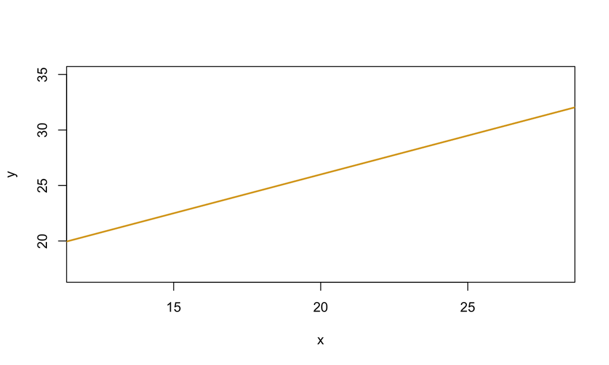

## The Sampling Distribution of \(\hat{\beta}_1\)

Assume the following true model:

\[ E(Y|X) = 12 + .7 * x; \epsilon \sim N(0, 4) \]

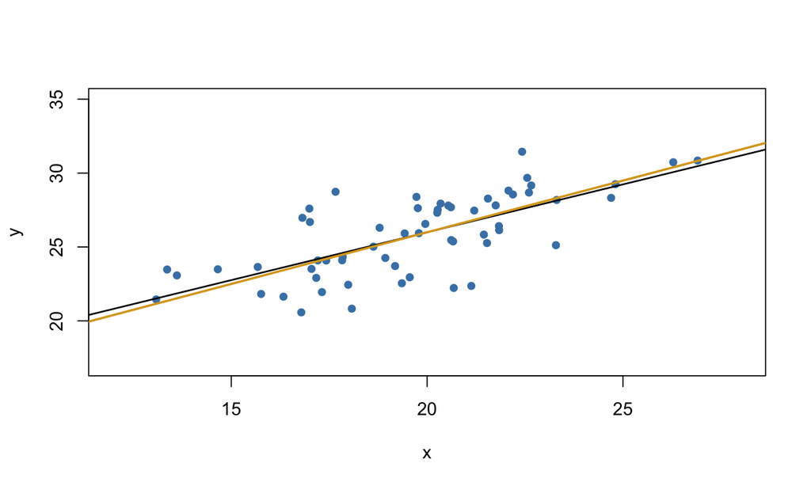

## The Sampling Distribution of \(\hat{\beta}_1\)

Assume the following true model:

\[ E(Y|X) = 12 + .7 * x; \epsilon \sim N(0, 4) \]

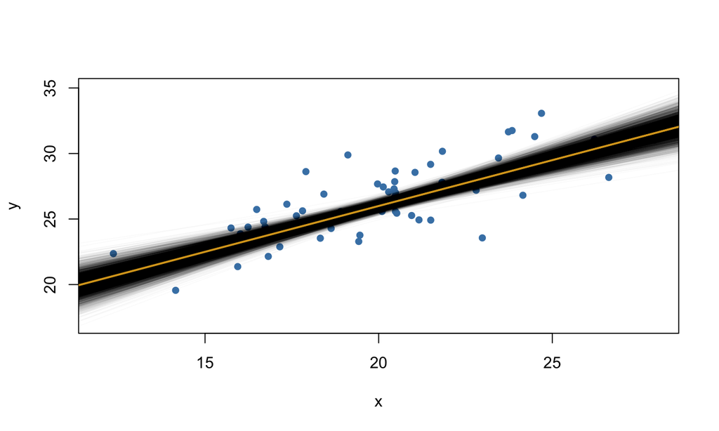

## The Sampling Distribution of \(\hat{\beta}_1\)

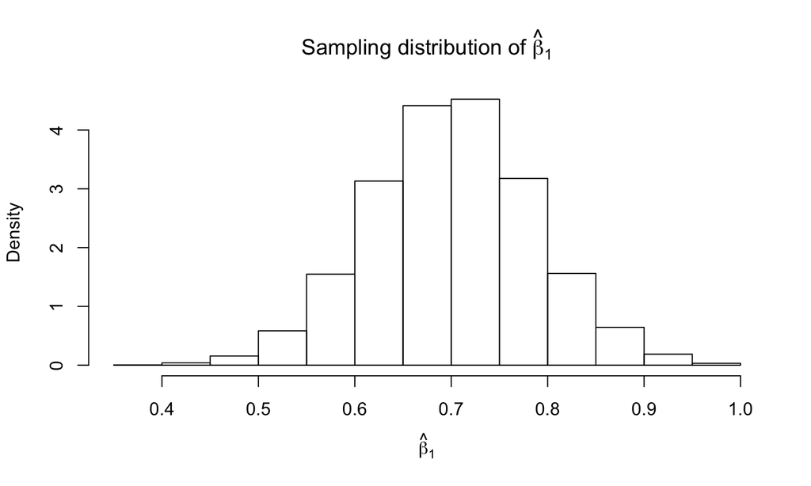

## The Sampling Distribution of \(\hat{\beta}_1\)

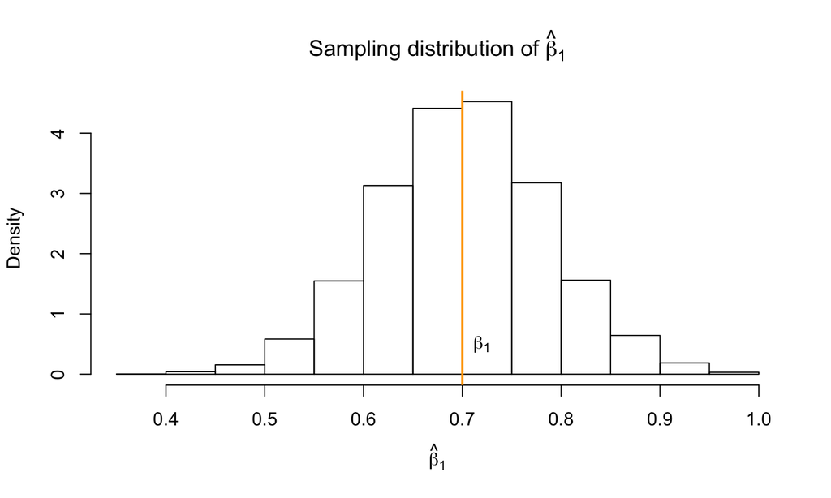

## The Sampling Distribution of \(\hat{\beta}_1\)

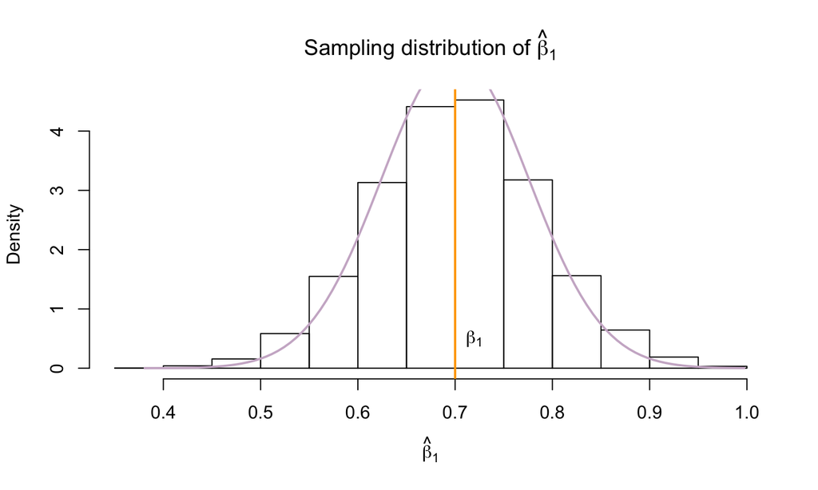

## The Sampling Distribution of \(\hat{\beta}_1\)

Characteristics:

1. Centered at \(\beta_1\), i.e. \(E(\hat{\beta}_1) = \beta\).
2. \(Var(\hat{\beta}_1) = \frac{\sigma^2}{SXX}\).
   - where \(SXX = \sum_{i = 1}^n (x_i - \bar{x})^2\)
3. \(\hat{\beta}_1 | X \sim N (\beta_1, \frac{\sigma^2}{SXX})\).

## Approximating the Sampling Dist. of \(\hat{\beta}_1\)

Our best guess of \(\beta_1\) is \(\hat{\beta}_1\). And since we have to estimate \(\sigma\) with \(\hat{\sigma}^2 = RSS/n-2\), the distribution isn't normal, but…

T with n - 2 degrees of freedom.

And we summarize that approximate sampling distribution using a CI:

\[ \hat{\beta}_1 \pm t_{\alpha/2, n-2} * SE(\hat{\beta}_1) \]

where

\[ SE(\hat{\beta}_1) = s/\sqrt(SXX) \]

## Interpreting a CI for \(\hat{\beta}_1\)

We are *95% confident* that the true slope between x and y lies between LB and UB.

## Hypothesis test for \(\hat{\beta}_1\)

Suppose we are interested in testing the claim that the slope is zero.

\[ H_0: \beta_1^0 = 0 \\ H_A: \beta_1^0 \ne 0 \]

We know that

\[ T = \frac{\hat{\beta}_1 - \beta_1^0}{SE(\hat{\beta}_1)} \]

T will be t distributed with \(n-2\) degrees of freedom and with \(SE(\hat{\beta}_1)\) calculated the same as in the CI.

## Inference for \(\hat{\beta}_0\)

Often less interesting (but not always!). You use the t-distribution again but with a different \(SE\).